# Ciência de Dados Descritiva - Lab1 (EDA)

# Informações iniciais

Para a análise, iremos utilizar os dados coletados para as séries Sherlock, Mr. Robot e Sense8.

```r
series_imdb = read_csv(here("data/series_from_imdb.csv"),
                    progress = FALSE,
                    col_types = cols(.default = col_double(),
                                     series_name = col_character(),
                                     episode = col_character(),
                                     url = col_character(),
                                     season = col_character())) %>%
    filter(series_name %in% c("Sherlock", "Mr Robot", "Sense8"))
```

| series_name | num_ep |
| --- | --- |
| Mr Robot - Temporada 1 | 10 |
| Mr Robot - Temporada 2 | 12 |
| Sense8 - Temporada 1 | 12 |
| Sense8 - Temporada 2 | 11 |
| Sherlock - Temporada 1 | 4 |
| Sherlock - Temporada 2 | 3 |
| Sherlock - Temporada 3 | 4 |
| Sherlock - Temporada 4 | 4 |

```
Mr Robot - Possui duas temporadas com 10 e 12 episódios cada uma, respectivamente.

Sense8 - Possui duas temporadas com 12 e 11 episódios cada uma, respectivamente.

Sherlock - Possui quatro temporadas com 4, 3, 4 e 4 episódios cada uma, respectivamente.
```

Antes de iniciar as análises, é necessário informar que por tomaremos por *avaliação* o significado literal, ou seja, a avaliação dada para cada episódio das séries escolhidas.

```r
summary(series_imdb %>%
            select(user_rating))
```

[output not shown]

Além disso, considerando os dados do sumário acima, temos por menor *avaliação* o valor 7.5, ou seja, iremos analisar informações apenas de r7, r8, r9 e r10 que indica a porcentagem de usuários que votaram nas notas 7, 8, 9 e 10 respectivamente.

```r
series_imdb %>%
  ggplot(aes(user_rating)) +
  geom_histogram(binwidth = .1, fill = "orange") +
  scale_x_continuous(breaks = seq(7, 10, 0.5)) +
  labs(y = "Número de ocorrências", x = "Avaliações dos episódios")
```

[output not shown]

Dados os valores dos quartis, é possível perceber que pelo menos **50%** dos valores estão concentrados em avaliações entre 8.6 e 9.2. Isso significa que as séries selecionadas possuem avaliações bastante positivas, visto que a mediana está em 8.9.

# Perguntas

## Qual das séries que você escolheu é mais bem avaliada no IMDB? A diferença é grande? Pequena?

Por se tratar de uma pergunta subjetiva, não há uma forma correta de definir a série mais bem avaliada.

A primeira e talvez mais tradicional forma é verificar a distribuição de notas para cada série. Encapsulando as temporadas e episódios, iremos utilizar a **média** e **mediana** para visualizar a série mais bem avaliada.

```r
series_imdb %>%
    group_by(series_name) %>%
    summarise(median_rating = median(user_rating),
              mean_rating = mean(user_rating)) %>%
    ggplot(aes(series_name)) +
    geom_point(aes(y = mean_rating, color = 'Média')) +
    geom_point(aes(y = median_rating, color = 'Mediana')) +
    labs(x = "Série", y = "Notas de Avaliação", color = "Métrica")
```

[output not shown]

Adotando essas formas de comparação, se escolhermos a **média** como fator determinante para uma série ser *bem avaliada* temos que a escolhida é **Mr Robot**.

Já se escolhermos a **mediana**, temos um aparente empate entre **Sense8** e **Sherlock**.

Portanto, essa não é a resposta que queremos. Devemos utilizar outra métrica de avaliação…

No nosso conjunto de dados temos as variáveis r1, r2… r10, que descrevem a proporção de avaliações com notas de 1 a 10.

```
"r1"          "r2"          "r3"          "r4"          "r5"          "r6"         "r7"          "r8"          "r9"          "r10"
```

Utilizaremos dessas variáveis como métrica para descobrir a série mais **bem avaliada**, ou seja, a que possuir mais ocorrências de notas maiores com mais constância.

```r
series_imdb %>%
    group_by(series_name) %>%
    arrange(series_name, season) %>%
    ggplot(aes(x = series_ep)) +
    geom_line(aes(y = r7, color = "Nota 7"), size = .8) +
    geom_line(aes(y = r8, color = "Nota 8"), size = .8) +
    geom_line(aes(y = r9, color = "Nota 9"), size = .8) +
    geom_line(aes(y = r10, color = "Nota 10"), size = .8) +
    facet_wrap(~ series_name) +
    labs(x = "Número do episódio", y = "Porcentagem de usuários",
         color = "Notas de avaliação")
```

[output not shown]

Com essa nova visualização, podemos perceber coisas interessantes:

### Sense8

Para Sense8, é possível perceber que a porcentagem de r10 é maior de 50% para mais da metade dos episódios da série, o que nos permite observar que a série se apresenta mais constante em suas avaliações.

Se observarmos os episódios partindo do 10 em diante, é possível perceber claramente a constância da série em apresentar uma boa qualidade para os espectadores, visto que há uma crescente muito relevante para r10.

### Sherlock

De forma semelhante a Sense8, Sherlock possui também uma porcentagem de r10 maior de 50% para mais da metade dos seus episódios, contudo, não apresenta a mesma constância. É possível perceber, a exemplo do episódio entre o 10 e 15 (talvez o 12 e 13) que há uma queda bem drástica. Que pode ser explicada ao analisar os episódios, onde um deles é um episódio extra de Natal *(The Abominable Bride)* que conta uma história bastante confusa à primeira vista.

### Conclusão

De acordo com a métrica selecionada, temos que há novamente um **empate** como ocorreu ao analisarmos a *mediana* mais acima, portanto, como critério de desempate vamos adotar a **constância** como sendo o fator determinante.

Portanto, chegamos à conclusão que **Sense8** possui uma maior constância e merece o título de **série mais bem avaliada** do Lab1.

`(~˘▾˘)~ Congrats!!! ~(˘▾˘~)`

## A avaliação das séries muda de acordo com as temporadas?

```r
series_imdb %>%
    ggplot(aes(season, user_rating, color = season)) +
    geom_boxplot() +
    geom_jitter(width = .2, alpha = .6) +
    facet_wrap(~series_name) +
    labs(x = "Temporada", y = "Nota dos episódios", color = "Temporada")
```

[output not shown]

### Mr Robot

```r
series_imdb %>%
  filter(series_name == "Mr Robot") %>%
  group_by(season) %>%
  summarise(min = min(user_rating),
            first_qu = quantile(user_rating, probs = c(0.25)),
            median = median(user_rating),
            mean = mean(user_rating),
            third_qu = quantile(user_rating, probs = c(0.75)),
            max = max(user_rating))
```

[output not shown]

A distribuição de valores de avaliação para a primeira temporada está entre 8.6 e 9.2 para o primeiro e terceiro quartil respectivamente, por outro lado, apesar de possuírem o mesmo valor para a mediana (8.8), a segunda temporada possui uma distribuição mais concentrada em valores entre 8.6 e 9.0, ou seja, um **IQR** *(intervalo interquartil)* relativamente baixo, o que nos dá a entender que a opinião das pessoas que assistiram e avaliaram os episódios da segunda temporada seguiram um mesmo consenso.

### Sense8

```r
series_imdb %>%
  filter(series_name == "Sense8") %>%
  group_by(season) %>%
  summarise(min = min(user_rating),
            first_qu = quantile(user_rating, probs = c(0.25)),
            median = median(user_rating),
            mean = mean(user_rating),
            third_qu = quantile(user_rating, probs = c(0.75)),
            max = max(user_rating))
```

[output not shown]

À primeira vista é possível perceber uma diferença muito grande entre as temporadas, pois enquanto a primeira temporada possui mediana próxima de 8.6 com alguns valores considerados *outliers* com avaliações muito mais baixas que o comum (7.5), a segunda temporada possui uma concentração de mais de **50%** (considerando partes dos quartis) com avaliação superior à 9.0 o que nos diz que, da mesma forma que ocorreu na segunda temorada de Mr Robot, também temos aqui um consenso entre os espectadores da série.

### Sherlock

```r
series_imdb %>%
  filter(series_name == "Sherlock") %>%
  group_by(season) %>%
  summarise(min = min(user_rating),
            first_qu = quantile(user_rating, probs = c(0.25)),
            median = median(user_rating),
            mean = mean(user_rating),
            third_qu = quantile(user_rating, probs = c(0.75)),
            max = max(user_rating))
```

[output not shown]

Apesar de ter poucos episódios por temporada, ainda assim é possível perceber o desenvolvimento da série. Nas transições de cada temporada é possível perceber mudanças muito discrepantes em relação a avaliação por episódio. O que podemos perceber de primeira é a queda de avaliação que acontece da terceira para a quarta temporada, onde a série tinha uma mediana de avaliação superior a 9.0 e na quarta temporada desceu abruptamente para 8.3.

### Conclusão

A partir das análises e da visualização do gráfico, é possível perceber que há sim, especialmente para **Sense8** e **Sherlock**, uma grande diferença entre a distribuição das avaliações ao decorrer das temporadas para cada série.

## Qual das séries que você escolheu tem episódios de qualidade mais irregular segundo o IMDB? A diferença é grande? Pequena?

### Métrica 1 - Amplitude

Para avaliar a irregularidade da qualidade de um episódio, iremos utilizar o conceito de amplitude, ou seja, uma série possui episódios irregulares quando a diferença entre um episódio e seu próximo se torna muito grande.

```r
series_imdb %>%
    mutate(user_rating.lag = if_else(is.na(lag(user_rating)), 0, user_rating - lag(user_rating))) %>%
    ggplot(aes(series_ep, user_rating.lag, color = as.factor(season))) +
    geom_jitter(width = .1) +
    geom_line() +
    geom_hline(yintercept = 0) +
    facet_wrap(~ series_name) +
    labs(x = "Número do episódio", y = "Nota dos usuários",
         color = "Temporada", title = "Variações entre episódios por temporada e por série")
```

[output not shown]

Para esta visualização, podemos perceber claramente que há muita variação de um episódio para outro em **Sherlock**. Apesar de também vermos muita variação nas outras séries, o que acontece em **Sherlock** é algo mais discrepante, visto que as distâncias de um episódio e o seu próximo são bem maiores do que nas outras séries, que possuem sim variações mas com pouca amplitude.

Outra coisa importante é que apesar de **Sense8** possuir descidas e subidas nas avaliações de seus episódios, podemos ver também que é a série em que mais de **50%** dos seus episódios estão acima da linha *(eixo y = 0)*, ou seja, possui uma variação positiva e portanto podemos pensar que é uma série mais constante mas com algumas quedas bruscas.

Portanto, podemos concluir que a série que possui qualidade mais irregular entre seus episódios é **Sherlock**.

### Métrica 2 - Variação

De outra forma…

```r
series_imdb %>%
    group_by(series_name) %>%
    mutate(user_rating.lag = if_else(is.na(lag(user_rating)), 0, user_rating - lag(user_rating))) %>%
    summarise(mean_rating_lag = mean(user_rating.lag)) %>%
    ggplot(aes(series_name)) +
    geom_point(aes(y = mean_rating_lag, color = 'Média')) +
    labs(x = "Série", y = "Variação de Avaliação", color = "Métrica")
```

[output not shown]

Podemos visualizar que a média, nesse caso, nos mostra se a variação é positiva ou negativa em relação a cada episódio avaliado.

Conseguimos ver que **Sense8**, como visto no gráfico mais acima possui mais de **50%** dos seus episódios com variação positiva, ou seja, acima da linha *(eixo y = 0)*. O que pode ser percebido nessa visualização.

E de forma semelhante, **Mr Robot** e **Sherlock** posuem muitas variações com grande amplitude passando pela linha *(eixo y = 0)*, ou seja, episódios com avaliações **irregulares** e uma variação negativa. O que também pode ser percebido na visualização.

### Conclusão

Tanto avaliando pela **métrica 1** como pela **métrica 2**, chegamos à conclusão que **Sherlock** possui tanto a maior **amplitude** entre os episódios como a maior **variação** negativa.

# Extra

## Qual das séries ou temporadas tem episódios mais sem graça? (Um episódio é sem graça se ninguém nem ama nem odeia ele)

Primeiramente iremos definir o que seria **amar** ou **odiar** um episódio. Para tal iremos utilizar algumas variáveis já conhecidas por nós: r1, r2, …, r9, r10. Mais especificamente, r1 e r10 que denotam a nota mínima (1) e nota máxima (10) respectivamente.

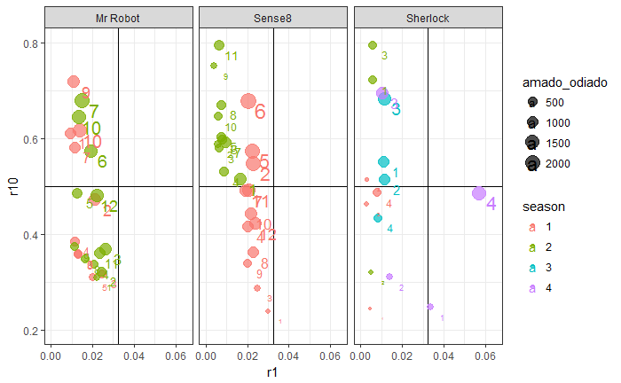

**IMPORTANTE: Os valores de r1 vão de 0 até 0.065 e os valores de r10 vão de 0.2 até 0.8, portanto a contagem de 50% será em relação a estes intervalos (como é possível observar visualmente)**

A partir do gráfico nós podemos ter quatro observações:

```
Quadrante superior esquerdo (1): indica os episódios que tiveram mais de 50% de amor e menos de 50% de ódio.
```

```
Quadrante superior direito (2): indica os episódios que tiveram mais de 50% de amor e também mais de 50% de ódio.
```

```
Quadrante inferior esquerdo (3): indica os episódios que tiveram menos de 50% de amor e menos de 50% de ódio.
```

```
Quadrante inferior direito (4): indica os episódios que tiveram menos de 50% de amor e mais de 50% de ódio.
```

Iremos considerar um episódio/temporada como sendo **sem graça** aqueles que estão no terceiro quadrante, ou seja, sem muito amor e sem muito ódio.

Dito isto, podemos analisar que todas as séries possuem uma quantidade proporcionalmente semelhante de episódios nesse quadrante. Analisando por temporada, temos que **Mr Robot** tem boa parte dos seus episódios tanto da primeira como da segunda temporada considerados como **sem graça** enquanto **Sense8** possui basicamente os da primeira temporada. **Sherlock** por sua vez também tem seus episódios dividos entre amados e odiados e além disso possui um ponto extremo que é o episódio 4 da quarta temporada, que está no quarto quadrante.

Visto que boa parte dos episódios estão no terceiro quadrante, não temos uma visualização exata de quem está tendo os episódios mais sem graça… Contudo, é possível perceber que no geral a primeira temporada é tida como mais **sem graça**, pois todas as séries possuem mais de 50% dos seus episódios dentro do terceiro quadrante.

Para tentarmos chegar a uma conclusão de outra forma, vamos separar dentre os que estão no terceiro quadrante, aqueles que têm menos 25% de amor e ódio. Observe a visualização abaixo:

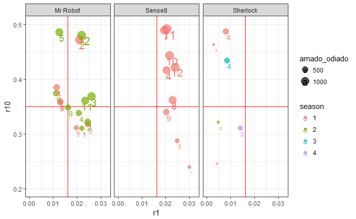

Fazendo a divisão de quadrantes de forma *recursiva* dentro do terceiro quadrante, podemos usar as classificações de forma análoga aos quadrantes definidos acima.

Portanto, para concluir qual das séries possui mais episódios **sem graça**, podemos dizer a seguinte frase:

```
Ora ora, temos um Xeroque Rolmes por aqui.
```

Sim, foi **Sherlock** a mais **sem graça**. Haha :^)